# R Notebook

# Selección del mejor subset

## Práctico 5a

Diploma Universitario en Ciencias Sociales Computacionales y Humanidades Digitales (UNSAM).

Módulo 3: Introducción al modelado de datos.

## Ridge Regression

Vamos a usar el dataset **Hitters** parte de la librería **ISLR**. Buscamos predecir el salario de un jugador de béisbol en base a diferentes variables estadísticas vinculadas a su performance durante el año previo.

Garantizá eliminar los valores perdidos en la variable **Salary**.

```r
install.packages("ISLR")
```

```r
library(ISLR)
dim(Hitters)
```

```
[1] 263  20
```

```r
Hitters=na.omit(Hitters)
```

**glmnet()** precisa que le pasemos como argumento una matriz **x** y un vector **y**. Vamos a realizar una regresión ridge para predecir **Salary** en el set de datos **Hitters**.

```r
x=model.matrix(Salary∼.,Hitters )[,-1]
y=Hitters$Salary
```

Usamos la función **glmnet()** con el argumento **alpha=0** para ajustar una regresión ridge.

```r
install.packages("glmnet", dependencies=TRUE)
library(glmnet)
```

Creamos valores de lambda.

```r
grid=10^seq(10,-2,length=100)
```

Dividimos entre train y test.

```r
set.seed(2)
train=sample(1:nrow(x),nrow(x)/2)
test=(-train)
y.test=y[test]
```

Fiteamos ridge y examinamos el valor en index número 60, que sería lambda = 705.

```r
ridge.mod=glmnet(x[train,],y[train],alpha=0,lambda=grid)
ridge.mod$lambda[60]
```

```
[1] 705.4802
```

```r
coef(ridge.mod)[,60]
```

```
  (Intercept)         AtBat          Hits         HmRun          Runs           RBI
 79.606056741   0.062061646   0.573805397   2.503780431   0.844206194   0.958147286
        Walks         Years        CAtBat         CHits        CHmRun         CRuns
  1.628966113   1.535096229   0.007687176   0.035987485   0.521092930   0.088308220
         CRBI        CWalks       LeagueN     DivisionW       PutOuts       Assists
  0.094129522   0.088661872  -0.978078347 -75.889472555   0.156898683   0.047553345
       Errors    NewLeagueN
 -0.725913771  -2.663888973
```

Calculamos ridge para lambda = 4.

```r
ridge.mod=glmnet(x[train,],y[train],alpha=0,lambda=grid)
ridge.pred=predict(ridge.mod,s=4,newx=x[test,])
mean((ridge.pred-y.test)^2)
```

```
[1] 107119.8
```

Calculamos la regresión solo utilizando OLS.

```r
ridge.pred=predict(ridge.mod,s=0,newx=x[test,])
mean((ridge.pred-y.test)^2)
```

```
[1] 111533.9
```

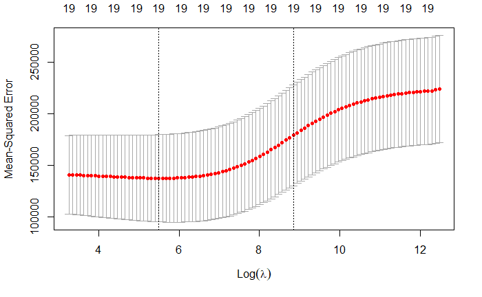

```r
set.seed(5)
cv.out=cv.glmnet(x[train,],y[train],alpha=0)
plot(cv.out)
```

```r
bestlam=cv.out$lambda.min
bestlam
```

```
[1] 243.564
```

El valor de lambda que presenta el error de validación cruzada más bajo es 243, ahora vamos a calcular el MSE asociado a ese valor de lambda.

```r
ridge.pred=predict(ridge.mod,s=bestlam,newx=x[test,])
mean((ridge.pred-y.test)^2)
```

```
[1] 98344.39
```

Calculamos nuestra regresión ridge con el mejor valor de lambda y vemos los coeficientes.

```r
out=glmnet(x,y,alpha=0)
predict(out,type="coefficients",s=bestlam)[1:20,]
```

```
 (Intercept)        AtBat         Hits        HmRun         Runs          RBI        Walks
 10.57017269   0.04881574   0.95599210   0.29580656   1.09870131   0.87641947   1.74401593
       Years       CAtBat        CHits       CHmRun        CRuns         CRBI       CWalks
  0.56975867   0.01125928   0.06234217   0.43657451   0.12396125   0.13171423   0.03803565
     LeagueN    DivisionW      PutOuts      Assists       Errors   NewLeagueN
 25.49617895 -87.72645229   0.18356063   0.03776918  -1.66145510   8.02556521
```

Ninguno de los coeficientes es cero, ridge regression NO selecciona variables!

## Lasso

Probemos ahora si un modelo lasso nos puede entregar mejores resultados. Debemos especificar **alpha=1** en **glmnet()** para indicar el uso de lasso.

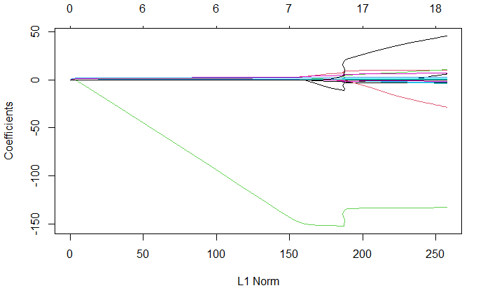

```r
lasso.mod=glmnet(x[train,],y[train],alpha=1,lambda=grid)
plot(lasso.mod)
```

Podemos ver en el plot que depende de la selección de parámetros de tuneo, algunos coeficientes seran iguales a cero. Ahora generemos una validación cruzada y computemos el error de test asociado.

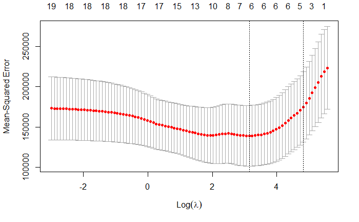

```r
set.seed(8)
cv.out=cv.glmnet(x[train,],y[train],alpha=1)
plot(cv.out)
```

```r
bestlam=cv.out$lambda.min
lasso.pred=predict(lasso.mod,s=bestlam,newx=x[test,])
mean((lasso.pred-y.test)^2)
```

```
[1] 101628.7
```

```r
out=glmnet(x,y,alpha=1,lambda=grid)
lasso.coef=predict(out,type="coefficients",s=bestlam)[1:20,]
lasso.coef
```

```
(Intercept)       AtBat        Hits       HmRun        Runs         RBI       Walks       Years
 33.8430900   0.0000000   1.8119984   0.0000000   0.0000000   0.0000000   2.1415568   0.0000000
     CAtBat       CHits      CHmRun       CRuns        CRBI      CWalks     LeagueN   DivisionW
  0.0000000   0.0000000   0.0000000   0.2016123   0.4032715   0.0000000   0.0000000 -91.7921633
    PutOuts     Assists      Errors  NewLeagueN
  0.2041296   0.0000000   0.0000000   0.0000000
```

```r
lasso.coef[lasso.coef!=0]
```

```
(Intercept)        Hits       Walks       CRuns        CRBI   DivisionW     PutOuts
 33.8430900   1.8119984   2.1415568   0.2016123   0.4032715 -91.7921633   0.2041296
```